# Lab 1: Looking at Datasets

Example Version: Titanic Data

September 27, 2018

## Introduction

```r
head(titanic)
```

```
##   Survived Pclass                                               Name
## 1        0      3                             Mr. Owen Harris Braund
## 2        1      1 Mrs. John Bradley (Florence Briggs Thayer) Cumings
## 3        1      3                              Miss. Laina Heikkinen
## 4        1      1        Mrs. Jacques Heath (Lily May Peel) Futrelle
## 5        0      3                            Mr. William Henry Allen
## 6        0      3                                    Mr. James Moran
##      Sex Age Siblings.Spouses.Aboard Parents.Children.Aboard    Fare
## 1   male  22                       1                       0  7.2500
## 2 female  38                       1                       0 71.2833
## 3 female  26                       0                       0  7.9250
## 4 female  35                       1                       0 53.1000
## 5   male  35                       0                       0  8.0500
## 6   male  27                       0                       0  8.4583
```

We will focus on two categorical variables: The passenger’s gender, and their travelling class.

```r
titanic_new <- titanic %>%
  mutate(
  Passenger.Class = factor(Pclass,
                           levels = c(1,2,3),
                           labels = c("First", "Second", "Third")),
  Survived = factor(Survived,
                    levels = c(0,1),
                    labels = c("Died", "Lived"))
  ) %>%
  select(Survived, Sex, Passenger.Class)

titanic_new %>% head()
```

```
##   Survived    Sex Passenger.Class
## 1     Died   male           Third
## 2    Lived female           First
## 3    Lived female           Third
## 4    Lived female           First
## 5     Died   male           Third
## 6     Died   male           Third
```

## The Titanic Dataset

There are three categorical variables in this dataset:  
* Survived, a binary variable of whether the passenger lived or died * Sex, a binary variable giving the passenger’s gender * Passenger.Class, a variable with three values for First, Second, or Third class travel

This sample was probably a convenience sample, since the dataset contains information about all the passengers for which records were availble.

This is an observational study.

## Research Questions

Question 1: Which class of passengers was most likely to survive? Question 2: Which gender was most likely to survive? Question 3: Is the relationship between survival and gender different for the three classes?

## Plotting single variables

Use the code chunk below to create an appropriate plot for each of your three categorical variables.

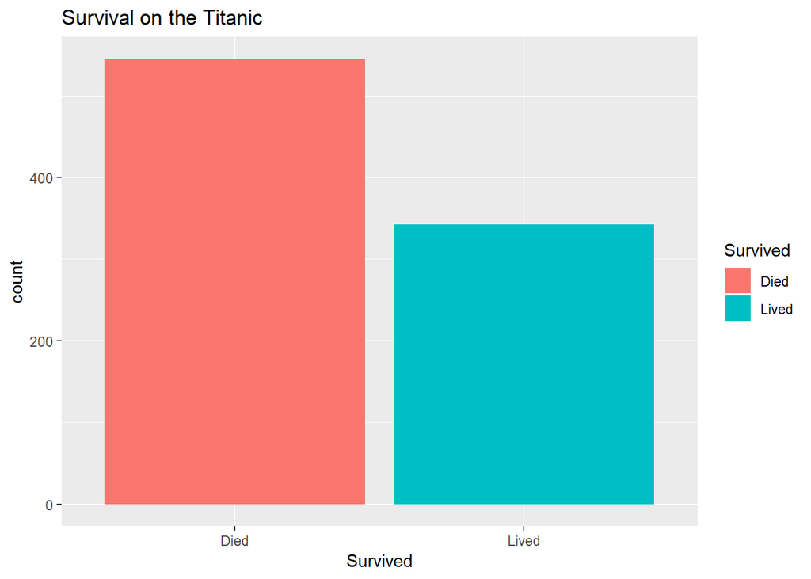

```r
ggplot(titanic_new, aes(x = Survived, fill = Survived)) + geom_bar() + ggtitle("Survival on the Titanic")
```

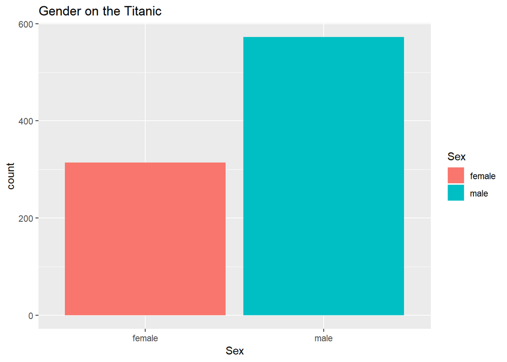

```r
ggplot(titanic_new, aes(x = Sex, fill = Sex)) + geom_bar() + ggtitle("Gender on the Titanic")
```

There were about 310 female passengers and about 580 male passengers in this dataset.

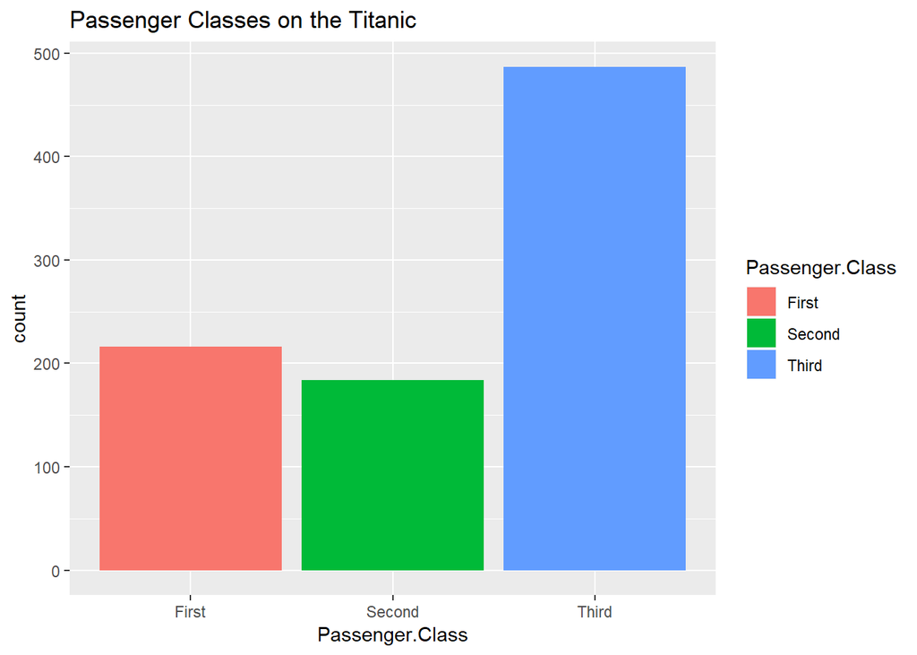

```r
ggplot(titanic_new, aes(x = Passenger.Class, fill = Passenger.Class)) + geom_bar() + ggtitle("Passenger Classes on the Titanic")
```

There were almost 500 passengers in third class, and about 200 in each of first and second class.

## Answering the research questions

### Question 1: Which class of passengers was most likely to survive?

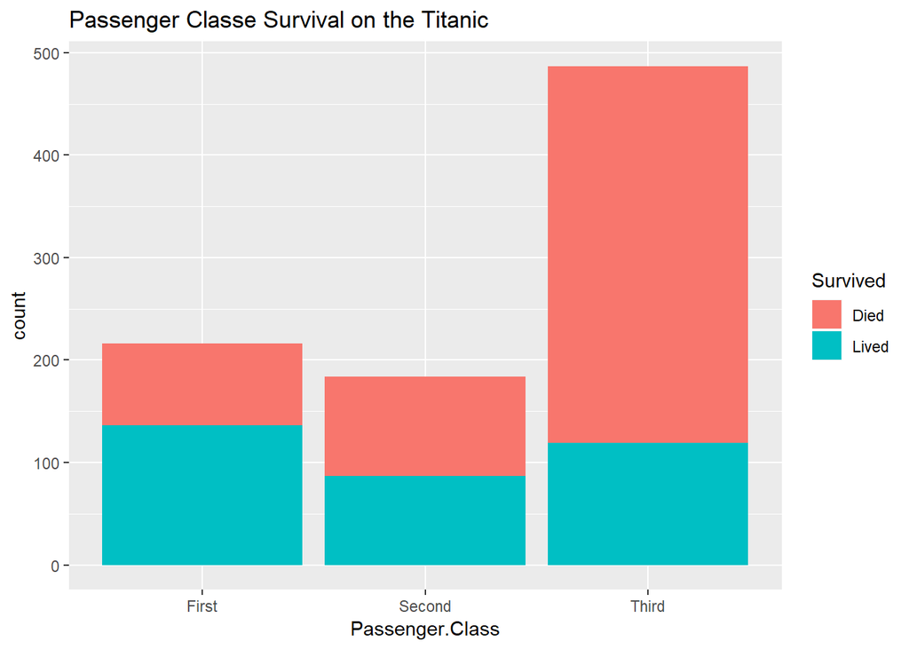

```r
ggplot(titanic_new, aes(x = Passenger.Class, fill = Survived)) + geom_bar() + ggtitle("Passenger Classe Survival on the Titanic")
```

About 75% of all third class passengers died, about 50% of second class, and about 33% of first class. This tells us that the richer passengers, traveling in the fancier classes, were more likely to escape off the sinking ship.

### Question 2: Which gender was most likely to survive?

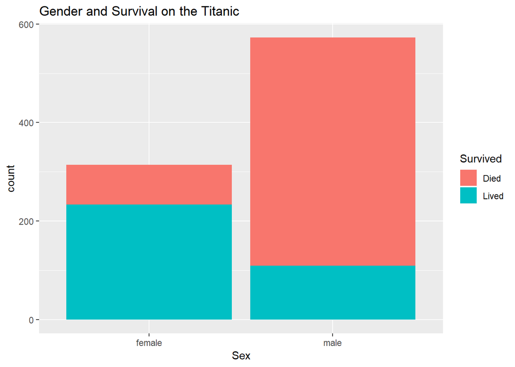

```r
ggplot(titanic_new, aes(x = Sex, fill = Survived)) + geom_bar() + ggtitle("Gender and Survival on the Titanic")
```

Around 80% of the male passengers died, compared only 20% of the female passengers. This makes sense, because on the Titanic, women and children were given lifeboats first.

### Question 3: Is the relationship between survival and gender different for the three classes?

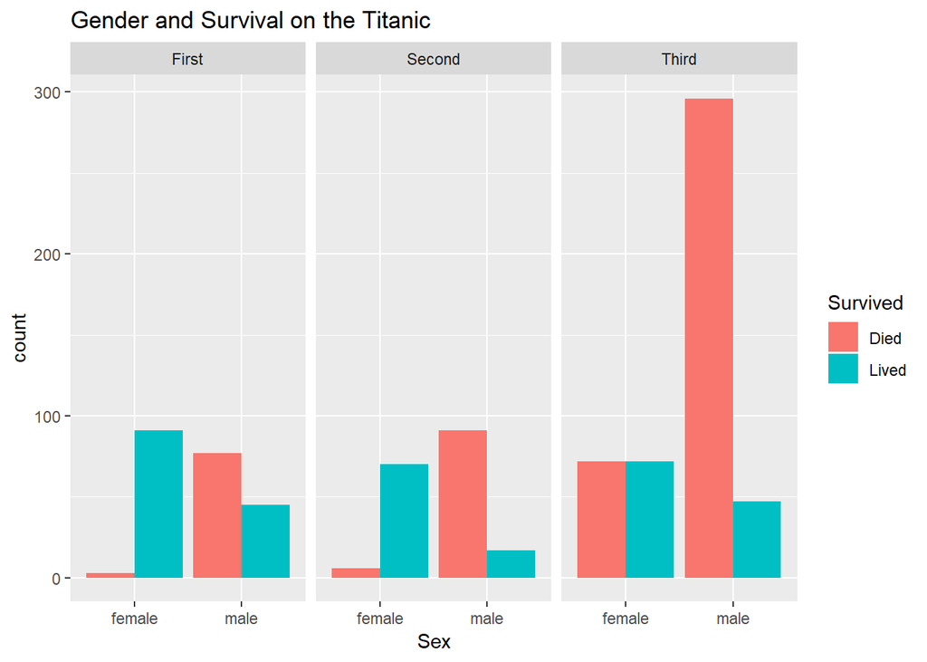

```r
ggplot(titanic_new, aes(x = Sex, fill = Survived)) + geom_bar(position = "dodge") + facet_wrap(~Passenger.Class)+ ggtitle("Gender and Survival on the Titanic")
```

In all classes, women survived more than men. However, the women in third class died at a much higher rate than the women in first or second class. This plot tells us that both gender and class mattered to survival, as we already knew.

But is the gender pattern *different* across the three classes?

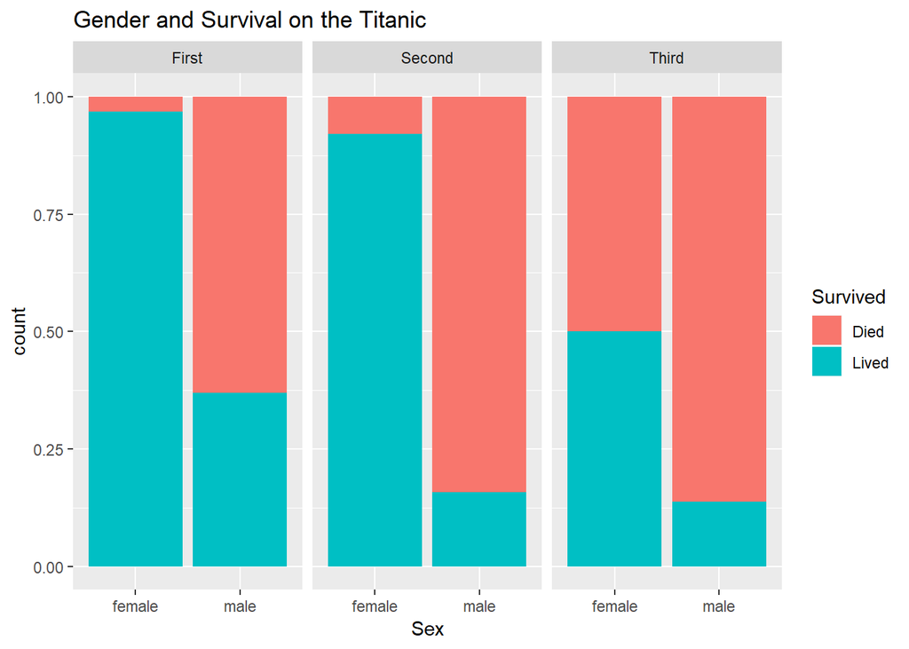

```r
ggplot(titanic_new, aes(x = Sex, fill = Survived)) + geom_bar(position = "fill") + facet_wrap(~Passenger.Class)+ ggtitle("Gender and Survival on the Titanic")
```

From this plot, we can conclude that the gender pattern *is* different for the three classes. First and second class were very similar, but in third class, the women were not nearly as favored (although they still survived more then the men).

This is an interesting nuance to the Titanic narrative. Yes, women and children were given lifeboats first - but this was mostly for the high class passengers. Working class women, travelling in third class, were much less likely to escape. We might think this has to do with location of rooms - perhaps 3rd class is further below deck - but we can see that men in 2nd class had almost the same chance of dying as 3rd class. Thus, a more likely explanation is that 3rd class women were treated differently.